# Bibliometrix analysis using journals

### Contents

1. Search string
2. General
3. Lotka’s Law coefficient estimation
4. Network matricies
5. Bibliographic coupling
6. Co-Word Analysis
7. Historical Direct Citation Network

### Search string

> TITLE ( ( social ) AND capability ) AND SUBJAREA ( arts OR busi OR deci OR econ OR psyc OR soci ) AND PUBYEAR > 1980 AND ( LIMIT-TO ( SRCTYPE , “j” ) ) AND ( LIMIT-TO ( DOCTYPE , “ar” ) )

Resulted in 417 documents in SCOPUS database. I decided to leave only journal articles, as conference papers tend to distort the general picture. Will analyze them separately. Searching only in the title. Otherwise getting more than 9000 results.

#### Plugin the library

```r
library(bibliometrix)
```

Load file (or several) \ - use double slash or normal slash - /

```r
myfile <- 'C:\\Users\\TL66LU\\Nextcloud\\GitHub\\aiprobono\\bibliometrix\\scopus social capabilities.bib'
```

Convert to r understandable structure

```r
bib_df<-convert2df(file = myfile, dbsource = "scopus", format = "bibtex")
```

```
Converting your scopus collection into a bibliographic dataframe

Done!


Generating affiliation field tag AU_UN from C1:  Done!
```

Analyze the data

```r
myresults <- biblioAnalysis(bib_df, sep = ";")
```

### General

Contents  
Summarize 10 results

```r
sor<-summary(myresults,10,FALSE)
```

```
MAIN INFORMATION ABOUT DATA

 Timespan                              1985 : 2021
 Sources (Journals, Books, etc)        297
 Documents                             417
 Average years from publication        6.11
 Average citations per documents       21.61
 Average citations per year per doc    2.673
 References                            24508

DOCUMENT TYPES
 article      417

DOCUMENT CONTENTS
 Keywords Plus (ID)                    838
 Author's Keywords (DE)                1181

AUTHORS
 Authors                               907
 Author Appearances                    994
 Authors of single-authored documents  134
 Authors of multi-authored documents   773

AUTHORS COLLABORATION
 Single-authored documents             137
 Documents per Author                  0.46
 Authors per Document                  2.18
 Co-Authors per Documents              2.38
 Collaboration Index                   2.76


Annual Scientific Production
```

| Year | Articles |
| --- | --- |
| 1985 | 1 |
| 1987 | 1 |
| 1995 | 2 |
| 1997 | 1 |
| 1998 | 3 |
| 1999 | 1 |
| 2000 | 4 |
| 2001 | 3 |
| 2002 | 3 |
| 2003 | 1 |

[output cut: 18 more lines]

```
Annual Percentage Growth Rate 8.677521


Most Productive Authors
```

|  | Authors | Articles | Authors | Articles Fractionalized |
| --- | --- | --- | --- | --- |
| 1 | DONATE MJ | 4 | WEAVER RL | 2.33 |
| 2 | GARCA-VILLAVERDE PM | 4 | NUSSBAUM M | 2.00 |
| 3 | PARRA-REQUENA G | 4 | WILSON-STRYDOM M | 2.00 |
| 4 | BENITEZ J | 3 | CAVAZOS-ARROYO J | 1.50 |
| 5 | LLORENS J | 3 | DENEULIN S | 1.50 |
| 6 | RUIZ-ORTEGA MJ | 3 | DYKER DA | 1.50 |
| 7 | SHENG ML | 3 | NA-ALLAH A | 1.50 |
| 8 | WEAVER RL | 3 | PUTTERMAN L | 1.50 |
| 9 | AGYAPONG A | 2 | RENOUARD C | 1.50 |
| 10 | BAPTISTA J | 2 | WALKER M | 1.50 |

```
Top manuscripts per citations
```

|  | Paper | DOI | TC | TCperYear | NTC |
| --- | --- | --- | --- | --- | --- |
| 1 | TRAINOR KJ, 2014, J BUS RES | 10.1016/j.jbusres.2013.05.002 | 354 | 44.2 | 11.33 |
| 2 | BLYLER M, 2003, STRATEGIC MANAGE J | 10.1002/smj.327 | 341 | 17.9 | 1.00 |
| 3 | KLASSEN RD, 2012, INT J PROD ECON | 10.1016/j.ijpe.2012.01.021 | 303 | 30.3 | 5.84 |
| 4 | BJRKMAN I, 2007, J INT BUS STUD | 10.1057/palgrave.jibs.8400287 | 303 | 20.2 | 5.18 |
| 5 | TEMPLE J, 1998, Q J ECON | 10.1162/003355398555711 | 260 | 10.8 | 2.02 |
| 6 | ANSARI S, 2012, J MANAGE STUD | 10.1111/j.1467-6486.2012.01042.x | 220 | 22.0 | 4.24 |
| 7 | CAPRON L, 2009, ORGAN SCI | 10.1287/orsc.1070.0328 | 193 | 14.8 | 3.48 |
| 8 | TIKLY L, 2011, INT J EDUC DEV | 10.1016/j.ijedudev.2010.06.001 | 180 | 16.4 | 6.57 |
| 9 | MISHINA Y, 2012, STRATEGIC MANAGE J | 10.1002/smj.958 | 160 | 16.0 | 3.08 |
| 10 | HOPPER K, 2007, SOC SCI MED | 10.1016/j.socscimed.2007.04.012 | 150 | 10.0 | 2.56 |

```
Corresponding Author's Countries
```

|  | Country | Articles | Freq | SCP | MCP | MCP_Ratio |
| --- | --- | --- | --- | --- | --- | --- |
| 1 | UNITED KINGDOM | 56 | 0.1713 | 47 | 9 | 0.1607 |
| 2 | CHINA | 47 | 0.1437 | 31 | 16 | 0.3404 |
| 3 | USA | 45 | 0.1376 | 40 | 5 | 0.1111 |
| 4 | AUSTRALIA | 16 | 0.0489 | 12 | 4 | 0.2500 |
| 5 | CANADA | 16 | 0.0489 | 11 | 5 | 0.3125 |
| 6 | ITALY | 14 | 0.0428 | 11 | 3 | 0.2143 |
| 7 | SOUTH AFRICA | 12 | 0.0367 | 10 | 2 | 0.1667 |
| 8 | SPAIN | 12 | 0.0367 | 11 | 1 | 0.0833 |
| 9 | INDIA | 9 | 0.0275 | 6 | 3 | 0.3333 |
| 10 | FINLAND | 8 | 0.0245 | 6 | 2 | 0.2500 |

```
SCP: Single Country Publications

MCP: Multiple Country Publications


Total Citations per Country
```

|  | Country | Total Citations | Average Article Citations |
| --- | --- | --- | --- |
| 1 | UNITED KINGDOM | 1823 | 32.55 |
| 2 | USA | 1727 | 38.38 |
| 3 | CHINA | 918 | 19.53 |
| 4 | CANADA | 604 | 37.75 |
| 5 | FINLAND | 503 | 62.88 |
| 6 | FRANCE | 371 | 61.83 |
| 7 | SPAIN | 233 | 19.42 |
| 8 | AUSTRALIA | 200 | 12.50 |
| 9 | NETHERLANDS | 145 | 48.33 |
| 10 | INDIA | 133 | 14.78 |

```
Most Relevant Sources
```

|  | Sources | Articles |
| --- | --- | --- |
| 1 | JOURNAL OF HUMAN DEVELOPMENT AND CAPABILITIES | 14 |
| 2 | JOURNAL OF BUSINESS RESEARCH | 11 |
| 3 | SUSTAINABILITY (SWITZERLAND) | 7 |
| 4 | JOURNAL OF BUSINESS ETHICS | 6 |
| 5 | INTERNATIONAL JOURNAL OF EDUCATIONAL DEVELOPMENT | 5 |
| 6 | SOCIAL WORK EDUCATION | 5 |
| 7 | INDUSTRIAL MARKETING MANAGEMENT | 4 |
| 8 | INFORMATION AND MANAGEMENT | 4 |
| 9 | INTERNATIONAL SOCIAL WORK | 4 |
| 10 | JOURNAL OF BUSINESS AND INDUSTRIAL MARKETING | 4 |

```
Most Relevant Keywords
```

[output not shown]

```
NA
```

Don’t know where it takes countries from. It parses it from some field.

Plot 10 results

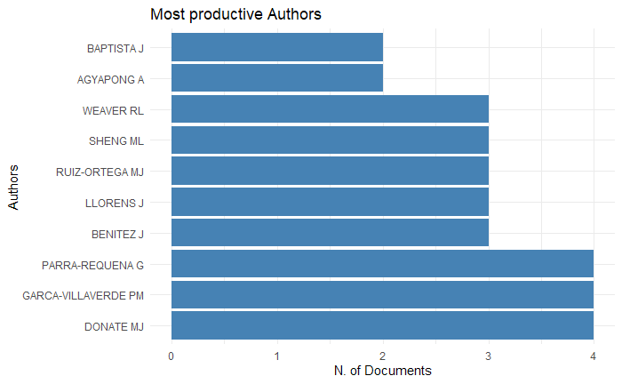

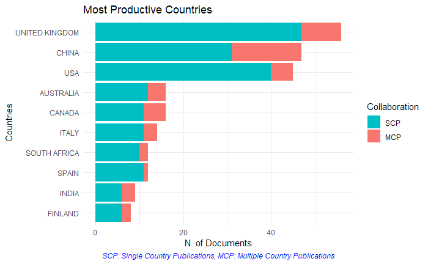

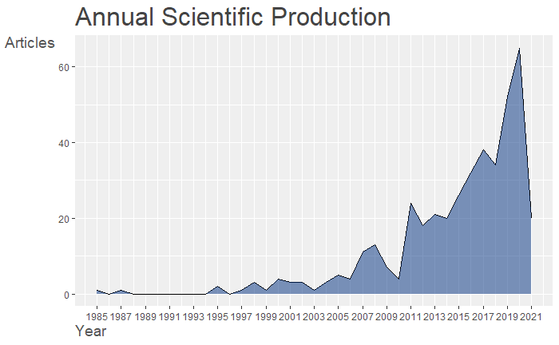

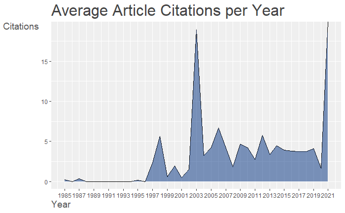

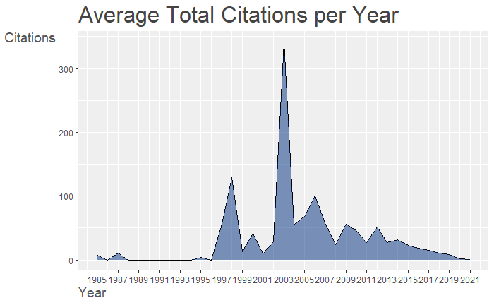

```r
plot(x=myresults,k=10,pause=FALSE)
```

Analyze citations and get 10 most cited articles

```r
CR<-citations(bib_df, field = "article", sep = ";")
cbind(CR$Cited[1:10])
```

```
                                                                                                                                                                                   [,1]
TEECE, D.J., PISANO, G., SHUEN, A., DYNAMIC CAPABILITIES AND STRATEGIC MANAGEMENT (1997) STRATEGIC MANAGEMENT JOURNAL, 18 (7), PP. 509-533                                           40
FORNELL, C., LARCKER, D.F., EVALUATING STRUCTURAL EQUATION MODELS WITH UNOBSERVABLE VARIABLES AND MEASUREMENT ERROR (1981) JOURNAL OF MARKETING RESEARCH, 18 (1), PP. 39-50          29
BARNEY, J., FIRM RESOURCES AND SUSTAINED COMPETITIVE ADVANTAGE (1991) JOURNAL OF MANAGEMENT, 17 (1), PP. 99-120                                                                      25
NAHAPIET, J., GHOSHAL, S., SOCIAL CAPITAL, INTELLECTUAL CAPITAL, AND THE ORGANIZATIONAL ADVANTAGE (1998) ACADEMY OF MANAGEMENT REVIEW, 23 (2), PP. 242-266                           24
TEECE, D.J., EXPLICATING DYNAMIC CAPABILITIES: THE NATURE AND MICROFOUNDATIONS OF (SUSTAINABLE) ENTERPRISE PERFORMANCE (2007) STRATEGIC MANAGEMENT JOURNAL, 28 (13), PP. 1319-1350   22
TSAI, W., GHOSHAL, S., SOCIAL CAPITAL AND VALUE CREATION: THE ROLE OF INTRAFIRM NETWORKS (1998) ACADEMY OF MANAGEMENT JOURNAL, 41 (4), PP. 464-476                                   20
EISENHARDT, K.M., MARTIN, J.A., DYNAMIC CAPABILITIES: WHAT ARE THEY? (2000) STRATEGIC MANAGEMENT JOURNAL, 21 (10-11), PP. 1105-1121                                                  19
DAY, G.S., THE CAPABILITIES OF MARKET-DRIVEN ORGANIZATIONS (1994) JOURNAL OF MARKETING, 58 (4), PP. 37-52                                                                            13
MORGAN, N.A., VORHIES, D.W., MASON, C.H., MARKET ORIENTATION, MARKETING CAPABILITIES, AND FIRM PERFORMANCE (2009) STRATEGIC MANAGEMENT JOURNAL, 30 (8), PP. 909-920                  13
ROBEYNS, I., THE CAPABILITY APPROACH: A THEORETICAL SURVEY (2005) JOURNAL OF HUMAN DEVELOPMENT, 6 (1), PP. 93-114                                                                    13
```

Analyze citations and get 10 most cited authors

```r
CR <- citations(bib_df, field = "author", sep = ";")
cbind(CR$Cited[1:10])
```

```
             [,1]
SEN A         435
NUSSBAUM M    160
TEECE D J     155
SEN A K       152
ROBEYNS I     130
GHOSHAL S     119
NUSSBAUM M C   97
PISANO G       91
ALKIRE S       84
FORNELL C      80
```

Local citations:

```r
CR <- localCitations(bib_df, sep = ";")
CR$Authors[1:10,]
```

|  | Author | LocalCitations |
| --- | --- | --- |
| 531 | MMBOGA AKALA B | 17 |
| 129 | CEGIELSKI C | 16 |
| 363 | JIA L | 16 |
| 439 | LEE KB | 16 |
| 716 | SHIN SI | 16 |
| 735 | SONG J | 16 |
| 900 | ZHOU Z | 16 |
| 758 | SURMEIER A | 10 |
| 43 | ASHFAQ M | 8 |
| 51 | BAHTA D | 8 |

```r
CR$Papers[1:10,]
```

|  | Paper | DOI | Year | LCS | GCS |
| --- | --- | --- | --- | --- | --- |
| 272 | TRAINOR KJ, 2014, J BUS RES | 10.1016/j.jbusres.2013.05.002 | 2014 | 17 | 354 |
| 398 | BLYLER M, 2003, STRATEGIC MANAGE J | 10.1002/smj.327 | 2003 | 16 | 341 |
| 387 | WALKER M, 2006, J EDUC POLICY | 10.1080/02680930500500245 | 2006 | 10 | 141 |
| 354 | DENEULIN S, 2010, EUR J SOC THEORY | 10.1177/1368431010382762 | 2010 | 8 | 133 |
| 182 | WANG Z, 2017, J INTERACT MARK | 10.1016/j.intmar.2017.02.004 | 2017 | 7 | 91 |
| 349 | TIKLY L, 2011, INT J EDUC DEV | 10.1016/j.ijedudev.2010.06.001 | 2011 | 6 | 180 |
| 316 | ANSARI S, 2012, J MANAGE STUD | 10.1111/j.1467-6486.2012.01042.x | 2012 | 5 | 220 |
| 358 | SMITH ML, 2009, J HUM DEV CAPABILITIES | 10.1080/19452820902940927 | 2009 | 5 | 92 |
| 243 | NGUYEN B, 2015, IND MARK MANAGE | 10.1016/j.indmarman.2015.04.017 | 2015 | 4 | 90 |
| 248 | LIU G, 2015, ENTREP THEORY PRACT | 10.1111/etap.12041 | 2015 | 4 | 62 |

Dominance ranking

```r
DF <- dominance(myresults, k = 10)
DF
```

|  | Author | Dominance Factor | Tot Articles | Single-Authored | Multi-Authored | First-Authored | Rank by Articles | Rank by DF |
| --- | --- | --- | --- | --- | --- | --- | --- | --- |
| 1 | BONVIN JM | 1.0000000 | 2 | 0 | 2 | 2 | 6 | 1 |
| 2 | BENITEZ J | 0.6666667 | 3 | 0 | 3 | 2 | 4 | 2 |
| 3 | SHENG ML | 0.6666667 | 3 | 0 | 3 | 2 | 4 | 2 |
| 4 | DONATE MJ | 0.5000000 | 4 | 0 | 4 | 2 | 1 | 4 |
| 5 | AGYAPONG A | 0.5000000 | 2 | 0 | 2 | 1 | 6 | 4 |
| 6 | BAPTISTA J | 0.5000000 | 2 | 0 | 2 | 1 | 6 | 4 |
| 7 | BELITZKY E | 0.5000000 | 2 | 0 | 2 | 1 | 6 | 4 |
| 8 | BJRKMAN I | 0.5000000 | 2 | 0 | 2 | 1 | 6 | 4 |
| 9 | GARCA-VILLAVERDE PM | 0.2500000 | 4 | 0 | 4 | 1 | 1 | 9 |
| 10 | PARRA-REQUENA G | 0.2500000 | 4 | 0 | 4 | 1 | 1 | 9 |

H-index

```r
authors=gsub(","," ",names(myresults$Authors)[1:10])
indices <- Hindex(bib_df, field = "author", elements=authors, sep = ";", years = 50)
indices$H
```

| Element | h_index | g_index | m_index | TC | NP | PY_start |
| --- | --- | --- | --- | --- | --- | --- |
| AGYAPONG A | 1 | 1 | 0.2500000 | 8 | 1 | 2018 |
| BAPTISTA J | 2 | 2 | 0.2857143 | 97 | 2 | 2015 |
| BENITEZ J | 3 | 3 | 0.7500000 | 132 | 3 | 2018 |
| DONATE MJ | 4 | 4 | 0.6666667 | 103 | 4 | 2016 |
| GARCA-VILLAVERDE PM | 4 | 4 | 0.3333333 | 72 | 4 | 2010 |
| LLORENS J | 3 | 3 | 0.7500000 | 132 | 3 | 2018 |
| PARRA-REQUENA G | 4 | 4 | 0.3333333 | 72 | 4 | 2010 |
| RUIZ-ORTEGA MJ | 3 | 3 | 0.2500000 | 68 | 3 | 2010 |
| SHENG ML | 3 | 3 | 0.4285714 | 55 | 3 | 2015 |
| WEAVER RL | 2 | 3 | 0.5000000 | 13 | 3 | 2018 |

### Lotka’s Law coefficient estimation

Contents

```r
L <- lotka(myresults)
# Author Productivity. Empirical Distribution
L$AuthorProd
```

| N.Articles | N.Authors | Freq |
| --- | --- | --- |
| 1 | 831 | 0.916207277 |
| 2 | 68 | 0.074972437 |
| 3 | 5 | 0.005512679 |
| 4 | 3 | 0.003307607 |

```r
# Beta
L$Beta
```

```
[1] 4.269819
```

```r
# Constatnt
L$C
```

```
[1] 0.9948464
```

```r
# Goodness of fit
L$R2
```

```
[1] 0.9778978
```

```r
# P-value of K-S two sample test
L$p.value
```

```
[1] 0.6993742
```

```r
# Observed distribution
Observed=L$AuthorProd[,3]

# Theoretical distribution with Beta = 2
Theoretical=10^(log10(L$C)-2*log10(L$AuthorProd[,1]))

plot(L$AuthorProd[,1],Theoretical,type="l",col="red",ylim=c(0, 1), xlab="Articles",ylab="Freq. of Authors",main="Scientific Productivity")
lines(L$AuthorProd[,1],Observed,col="blue")
```

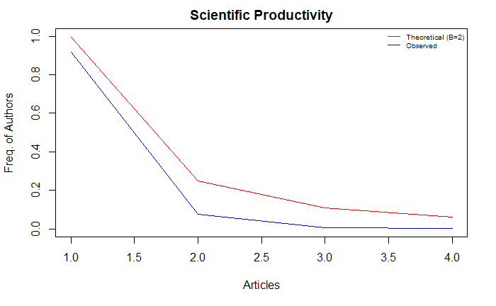

```r
legend(x="topright",c("Theoretical (B=2)","Observed"),col=c("red","blue"),lty = c(1,1,1),cex=0.6,bty="n")
```

Don’t know how to comment upon these results. Does this mean authors are being not that productive?

### Network matricies

Contents

#### Biparite networks

```r
A <- cocMatrix(bib_df, Field = "SO", sep = ";")
sort(Matrix::colSums(A), decreasing = TRUE)[1:5]
```

```
   JOURNAL OF HUMAN DEVELOPMENT AND CAPABILITIES                     JOURNAL OF BUSINESS RESEARCH                     SUSTAINABILITY (SWITZERLAND)
                                              14                                               11                                                7
                      JOURNAL OF BUSINESS ETHICS INTERNATIONAL JOURNAL OF EDUCATIONAL DEVELOPMENT
                                               6                                                5
```

#### Citation network

```r
A <- cocMatrix(bib_df, Field = "CR", sep = ".  ")
sort(Matrix::colSums(A), decreasing = TRUE)[1:5]
```

```
                                                                                                       ALKIRE S. (2002)
                                                                                                                     13
                                                      ABRAMOVITZ M. CATCHING UP FORGING AHEAD AND FALLING BEHIND (1986)
                                                                                                                      9
ACQUAAH M. MANAGERIAL SOCIAL CAPITAL STRATEGIC ORIENTATION AND ORGANIZATIONAL PERFORMANCE IN AN EMERGING ECONOMY (2007)
                                                                                                                      8
                                                ADLER P.S. KWON S.W. SOCIAL CAPITAL: PROSPECTS FOR A NEW CONCEPT (2002)
                                                                                                                      6
                                                    ADLER P. KWON S. SOCIAL CAPITAL: PROSPECTS FOR A NEW CONCEPT (2002)
                                                                                                                      4
```

Did not understand how to interpret it.

#### Author network

```r
 A <- cocMatrix(bib_df, Field = "AU", sep = ";")
sort(Matrix::colSums(A), decreasing = TRUE)[1:5]
```

```
          DONATE MJ GARCA-VILLAVERDE PM     PARRA-REQUENA G           BENITEZ J           LLORENS J
                  4                   4                   4                   3                   3
```

#### Country network

```r
AuCo <- metaTagExtraction(bib_df, Field = "AU_CO", sep = ";")
A <- cocMatrix(AuCo, Field = "AU_CO", sep = ";")
sort(Matrix::colSums(A), decreasing = TRUE)[1:10]
```

```
UNITED KINGDOM            USA          CHINA      AUSTRALIA         CANADA          SPAIN          ITALY         FRANCE        GERMANY   SOUTH AFRICA
            83             69             53             28             22             20             20             17             16             15
```

#### Author keyword nw

```r
A <- cocMatrix(bib_df, Field = "DE", sep = ";")
sort(Matrix::colSums(A), decreasing = TRUE)[1:100]
```

```
                  SOCIAL CAPITAL                     CAPABILITIES              CAPABILITY APPROACH             DYNAMIC CAPABILITIES                   SOCIAL JUSTICE
                              50                               40                               37                               25                               20
                    SOCIAL MEDIA                       CAPABILITY                       INNOVATION            CAPABILITIES APPROACH  CORPORATE SOCIAL RESPONSIBILITY
                              20                               18                               18                               14                               14
           INNOVATION CAPABILITY                  SOCIAL NETWORKS               DYNAMIC CAPABILITY           MARKETING CAPABILITIES                             SMES
                              11                               10                                9                                9                                9
                           CHINA                      PERFORMANCE                SOCIAL INNOVATION                       DISABILITY             MARKETING CAPABILITY
                               8                                8                                8                                7                                7
               SOCIAL ENTERPRISE                      SOCIAL WORK              ABSORPTIVE CAPACITY                      AMARTYA SEN                      DEVELOPMENT
                               7                                7                                6                                6                                6
                FIRM PERFORMANCE                           GENDER                HUMAN DEVELOPMENT                          POVERTY                              SEN
                               6                                6                                6                                6                                6
               SOCIAL CAPABILITY                     SOCIAL VALUE            COMPETITIVE ADVANTAGE                        EDUCATION                KNOWLEDGE SHARING
                               6                                6                                5                                5                                5
                 QUALITY OF LIFE                 SOCIAL EXCLUSION                 SOCIAL INCLUSION           SOCIAL MEDIA MARKETING       TECHNOLOGICAL CAPABILITIES
                               5                                5                                5                                5                                5
                           TRUST        BUSINESS MODEL INNOVATION      ENTREPRENEURIAL ORIENTATION             FINANCIAL CAPABILITY                          FREEDOM
                               5                                4                                4                                4                                4
                      GOVERNANCE                     HUMAN RIGHTS          INNOVATION CAPABILITIES        INTERNATIONAL PERFORMANCE                          JUSTICE
                               4                                4                                4                                4                                4
              MARKET ORIENTATION                        MARKETING                         NUSSBAUM                  OPEN INNOVATION              RESOURCE-BASED VIEW
                               4                                4                                4                                4                                4
           SOCIAL CAPITAL THEORY          SOCIAL ENTREPRENEURSHIP                   SUSTAINABILITY                       WELL-BEING                        WELLBEING
                               4                                4                                4                                4                                4
                      BANGLADESH                       CASE STUDY                         CHILDREN                              CRM                              CSR
                               3                                3                                3                                3                                3
```

[output cut: 14 more lines]

#### Keyword nw

```r
A <- cocMatrix(bib_df, Field = "ID", sep = ";")
sort(Matrix::colSums(A), decreasing = TRUE)[1:30]
```

```
                      HUMAN                     ARTICLE  SOCIAL NETWORKING (ONLINE)              SOCIAL JUSTICE                  INNOVATION
                         29                          18                          16                          15                          15
               SOCIAL MEDIA                      HUMANS                      FEMALE                        MALE              SOCIAL CAPITAL
                         14                          14                          13                          13                          13
          THEORETICAL STUDY                       ADULT            HUMAN EXPERIMENT                    LEARNING                 SOCIAL WORK
                         13                          11                          11                           9                           9
                 PSYCHOLOGY                   MARKETING ECONOMIC AND SOCIAL EFFECTS                       CHINA                    COMMERCE
                          9                           8                           8                           7                           7
                      SALES                   WELLBEING             DECISION MAKING           CAPACITY BUILDING                   EDUCATION
                          7                           7                           6                           6                           6
                  KNOWLEDGE        MAJOR CLINICAL STUDY              SOCIAL NETWORK               SOCIAL THEORY     SUSTAINABLE DEVELOPMENT
                          6                           6                           6                           6                           6
```

#### Page count nw

Doesn’t work as the dataset has no such a field.

### Bibliographic coupling

Contents

[figure not shown]

```r
NetMatrix <- biblioNetwork(bib_df, analysis = "coupling", network = "authors", sep = ";")
```

#### Collaborating authors

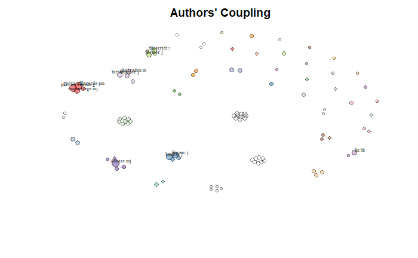

```r
NetMatrix <- biblioNetwork(bib_df, analysis = "collaboration", network = "authors", sep = ";")
net=networkPlot(NetMatrix,  normalize = "salton", weighted=NULL, n = 100, Title = "Authors' Coupling", type = "fruchterman", size=5,size.cex=T,remove.multiple=TRUE,labelsize=0.5,label.n=10,label.cex=F)
```

#### Co-citation

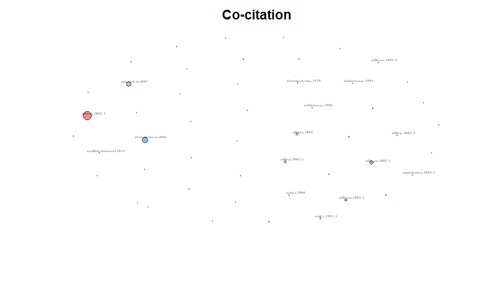

```r
NetMatrix <- biblioNetwork(bib_df, analysis = "co-citation", network = "references", sep = ".  ")
net=networkPlot(NetMatrix,  normalize = "salton", weighted=NULL, n = 50, Title = "Co-citation", type = "fruchterman", size=5,size.cex=T,remove.multiple=TRUE,labelsize=0.3,label.n=10,label.cex=F)
```

#### Co-citation network

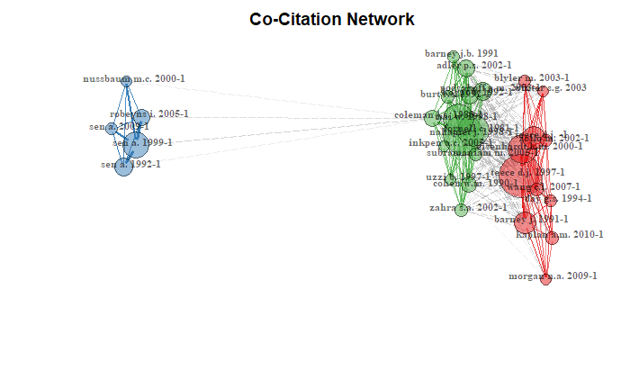

```r
NetMatrix <- biblioNetwork(bib_df, analysis = "co-citation", network = "references", sep = ";")

# Plot the network
net=networkPlot(NetMatrix, n = 30, Title = "Co-Citation Network", type = "fruchterman", size=T, remove.multiple=FALSE, labelsize=0.7,edgesize = 5)
```

#### Keyword co-occurrences

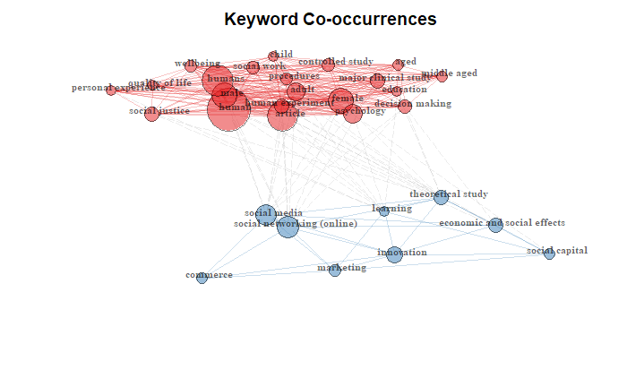

```r
NetMatrix <- biblioNetwork(bib_df, analysis = "co-occurrences", network = "keywords", sep = ";")

# Plot the network
net=networkPlot(NetMatrix, normalize="association", weighted=T, n = 30, Title = "Keyword Co-occurrences", type = "fruchterman", size=T,edgesize = 5,labelsize=0.7)
```

### Co-Word Analysis: The conceptual structure of a field

Contents

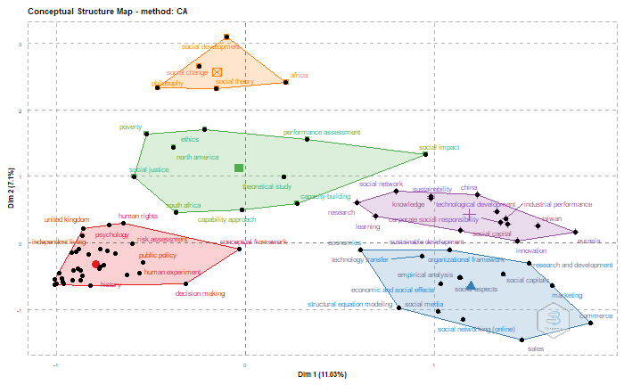

[figure not shown]

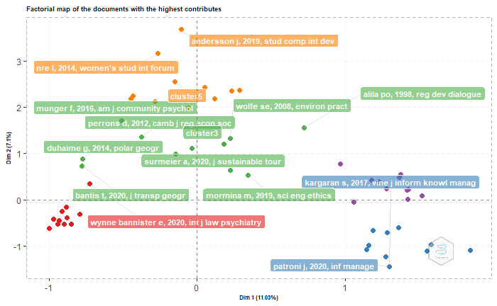

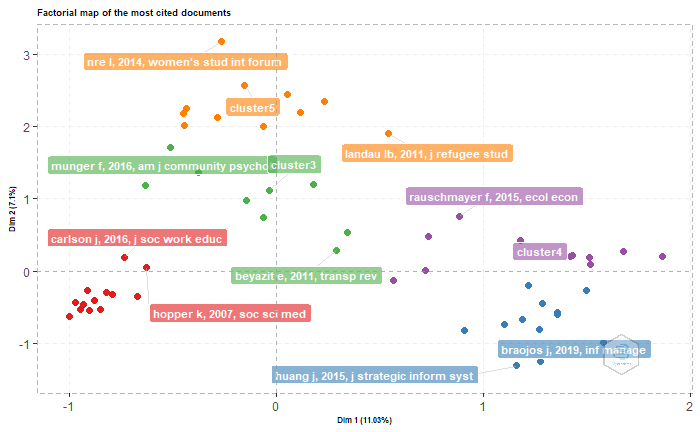

```r
CS <- conceptualStructure(bib_df,field="ID", method="CA", minDegree=4, clust=5, stemming=FALSE, labelsize=6, documents=10)
```

### Historical Direct Citation Network

```r
options(width=130)
histResults <- histNetwork(bib_df, min.citations = 1, sep = ";")
```

```
SCOPUS DB: Searching local citations (LCS) by document titles (TI) and DOIs...

Found 93 documents with no empty Local Citations (LCS)
```

```
 Legend
```

| Label | DOI | Year | LCS | GCS |
| --- | --- | --- | --- | --- |
| SLABBERT I, 2018, SOC WORK EDUC | 10.1080/02615479.2018.1458830 | 2018 | 2 | 2 |
| PINHO JC, 2016, J WORLD BUS | 10.1016/j.jwb.2015.08.001 | 2016 | 3 | 58 |
| DOS SANTOS SSS, 2020, REV BRAS MARK | 10.5585/remark.v19i1.17346 | 2020 | 0 | 0 |
| KJELLBERG I, 2020, INT SOC WORK | 10.1177/0020872819896849 | 2020 | 0 | 0 |
| GHADERI H, 2020, INT J LEARN INTELLECT CAP | 10.1504/IJLIC.2020.113148 | 2020 | 0 | 0 |

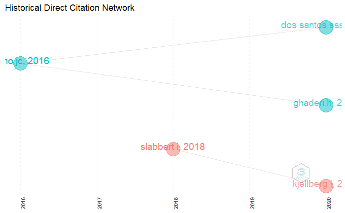

```r
net <- histPlot(histResults, n=15, size = 10, labelsize=5)
```